# Project: Identify Customer Segments

### Step 3.2: Apply All Steps to the Customer Data

Now that you have clusters and cluster centers for the general population, it's time to see how the customer data maps on to those clusters. Take care to not confuse this for re-fitting all of the models to the customer data. Instead, you're going to use the fits from the general population to clean, transform, and cluster the customer data. In the last step of the project, you will interpret how the general population fits apply to the customer data.

- Don't forget when loading in the customers data, that it is semicolon (`;`) delimited.
- Apply the same feature wrangling, selection, and engineering steps to the customer demographics using the `clean_data()` function you created earlier. (You can assume that the customer demographics data has similar meaning behind missing data patterns as the general demographics data.)
- Use the sklearn objects from the general demographics data, and apply their transformations to the customers data. That is, you should not be using a `.fit()` or `.fit_transform()` method to re-fit the old objects, nor should you be creating new sklearn objects! Carry the data through the feature scaling, PCA, and clustering steps, obtaining cluster assignments for all of the data in the customer demographics data.

```python
# Load in the customer demographics data.
import pandas as pd
customers = pd.read_csv("Udacity_CUSTOMERS_Subset.csv", sep=";")
```

```python
# Apply preprocessing, feature transformation, and clustering from the general
# demographics onto the customer data, obtaining cluster predictions for the
# customer demographics data.
customers.shape
```

```
(191652, 85)
```

```python
undrop_list
```

```
Index(['ALTERSKATEGORIE_GROB', 'ANREDE_KZ', 'CJT_GESAMTTYP',
       'FINANZ_MINIMALIST', 'FINANZ_SPARER', 'FINANZ_VORSORGER',
       'FINANZ_ANLEGER', 'FINANZ_UNAUFFAELLIGER', 'FINANZ_HAUSBAUER',
       'FINANZTYP', 'GFK_URLAUBERTYP', 'GREEN_AVANTGARDE', 'HEALTH_TYP',
       'LP_LEBENSPHASE_FEIN', 'LP_LEBENSPHASE_GROB', 'LP_FAMILIE_FEIN',
       'LP_FAMILIE_GROB', 'LP_STATUS_FEIN', 'LP_STATUS_GROB',
       'NATIONALITAET_KZ', 'PRAEGENDE_JUGENDJAHRE', 'RETOURTYP_BK_S',
       'SEMIO_SOZ', 'SEMIO_FAM', 'SEMIO_REL', 'SEMIO_MAT', 'SEMIO_VERT',
       'SEMIO_LUST', 'SEMIO_ERL', 'SEMIO_KULT', 'SEMIO_RAT', 'SEMIO_KRIT',
       'SEMIO_DOM', 'SEMIO_KAEM', 'SEMIO_PFLICHT', 'SEMIO_TRADV',
       'SHOPPER_TYP', 'SOHO_KZ', 'VERS_TYP', 'ZABEOTYP', 'ANZ_PERSONEN',
       'ANZ_TITEL', 'HH_EINKOMMEN_SCORE', 'W_KEIT_KIND_HH', 'WOHNDAUER_2008',
       'ANZ_HAUSHALTE_AKTIV', 'ANZ_HH_TITEL', 'GEBAEUDETYP', 'KONSUMNAEHE',
       'MIN_GEBAEUDEJAHR', 'OST_WEST_KZ', 'WOHNLAGE', 'CAMEO_DEUG_2015',
       'CAMEO_DEU_2015', 'CAMEO_INTL_2015', 'KBA05_ANTG1', 'KBA05_ANTG2',
       'KBA05_ANTG3', 'KBA05_ANTG4', 'KBA05_GBZ', 'BALLRAUM', 'EWDICHTE',
       'INNENSTADT', 'GEBAEUDETYP_RASTER', 'KKK', 'MOBI_REGIO',
       'ONLINE_AFFINITAET', 'REGIOTYP', 'KBA13_ANZAHL_PKW', 'PLZ8_ANTG1',
       'PLZ8_ANTG2', 'PLZ8_ANTG3', 'PLZ8_ANTG4', 'PLZ8_BAUMAX', 'PLZ8_HHZ',
       'PLZ8_GBZ', 'ARBEIT', 'ORTSGR_KLS9', 'RELAT_AB'],
      dtype='object')
```

```python
newundrop_list = undrop_list.drop('CAMEO_DEU_2015')
```

```python
clean_cf = to_nan(customers)
print(clean_cf.shape)

remove_dellist(dellist, clean_cf)

undrop_index = undrop_list_index(clean_cf)
print(clean_cf.shape)

clean_cf = new_cameo_deu(clean_cf)
print(clean_cf.shape)
```

[output not shown]

[output cut: 279 more lines]

```
['-1', '0']
-1
ORTSGR_KLS9
0.0
ORTSGR_KLS9
['-1', '9']
-1
RELAT_AB
9.0
RELAT_AB
(191652, 85)
['GREEN_AVANTGARDE', 'SOHO_KZ', 'TITEL_KZ', 'VERS_TYP', 'ANZ_PERSONEN', 'ANZ_TITEL', 'ANZ_HAUSHALTE_AKTIV', 'ANZ_HH_TITEL', 'MIN_GEBAEUDEJAHR', 'OST_WEST_KZ', 'PLZ8_ANTG4', 'AGER_TYP', 'GEBURTSJAHR', 'ALTER_HH', 'KK_KUNDENTYP', 'KBA05_BAUMAX']
(191652, 85)
{'1A': 1, '1B': 2, '1C': 3, '1D': 4, '1E': 5, '2A': 6, '2B': 7, '2C': 8, '2D': 9, '3A': 10, '3B': 11, '3C': 12, '3D': 13, '4A': 14, '4B': 15, '4C': 16, '4D': 17, '4E': 18, '5A': 19, '5B': 20, '5C': 21, '5D': 22, '5E': 23, '5F': 24, '6A': 25, '6B': 26, '6C': 27, '6D': 28, '6E': 29, '6F': 30, '7A': 31…
(191652, 85)
```

```python
clean_cf = clean_cf.iloc[:, undrop_index]
print(clean_cf.shape)
clean_cf = clean_data(clean_cf)
```

```
(191652, 79)
[1, 2, 3, 4, 5, 6, 7, 8, 9, 10, 11, 12, 13, 14, 15]
['EW', 'EW', 'EW', 'EW', 'EW', 'W', 'E', 'EW', 'EW', 'W', 'W', 'E', 'E', 'EW', 'EW']
{1: 'EW', 2: 'EW', 3: 'EW', 4: 'EW', 5: 'EW', 6: 'W', 7: 'E', 8: 'EW', 9: 'EW', 10: 'W', 11: 'W', 12: 'E', 13: 'E', 14: 'EW', 15: 'EW'}
0         1
1         0
2         1
3         1
4         1
5         1
6         1
7         1
8         1
9         1
10        1
```

[output cut: 237 more lines]

```python
clean_cf = del_fein(clean_cf)
```

```python
print(clean_cf.shape)
clean_cf.isna().sum()
```

```
(191652, 103)
```

```
ALTERSKATEGORIE_GROB          240
ANREDE_KZ                       0
CJT_GESAMTTYP                3213
FINANZ_MINIMALIST               0
FINANZ_SPARER                   0
FINANZ_VORSORGER                0
FINANZ_ANLEGER                  0
FINANZ_UNAUFFAELLIGER           0
FINANZ_HAUSBAUER                0
FINANZTYP                       0
GFK_URLAUBERTYP              3213
GREEN_AVANTGARDE                0
HEALTH_TYP                  48990
LP_FAMILIE_GROB             50582
LP_STATUS_GROB               3213
NATIONALITAET_KZ            48750
RETOURTYP_BK_S               3213
SEMIO_SOZ                       0
SEMIO_FAM                       0
SEMIO_REL                       0
SEMIO_MAT                       0
SEMIO_VERT                      0
SEMIO_LUST                      0
SEMIO_ERL                       0
SEMIO_KULT                      0
SEMIO_RAT                       0
SEMIO_KRIT                      0
SEMIO_DOM                       0
SEMIO_KAEM                      0
SEMIO_PFLICHT                   0
                            ...
youth_50s                       0
youth_60s                       0
youth_70s                       0
youth_80s                       0
youth_90s                       0
youth_EW                        0
youth_E                         0
youth_W                         0
youth_main_avantg               0
hhd_wealthy                     0
hhd_prosperous                  0
hhd_comfortable                 0
hhd_l_affluent                  0
hhd_poorer                      0
prefamily_singles               0
young_children                  0
family_school_age               0
older_fam_mature_couples        0
retired                         0
family_status_unknown           0
lifestage_single                0
lifestage_couple                0
lifestage_single_p              0
lifestage_family                0
lifestage_la_$                  0
lifestage_na_$                  0
lifestage_higher_$              0
lifestage_younger               0
lifestage_older                 0
lifestage_age_na                0
Length: 103, dtype: int64
```

```python
print(df_clean.shape)
print(clean_cf.shape)
```

```
(891221, 103)
(191652, 103)
```

```python
# review suggested to use transform without fit though this does not work therefore I am using fit()
# ???? try to inherit the object transformed by imputer to scaler to pca without using fit() as of review
# NotFittedError


customer_imputer = simputer.transform(clean_cf)
```

```python
pd.DataFrame(customer_imputer).isna().sum().sum()
```

```
0
```

```python
customer_imputer_scaler = scaler_fit.transform(customer_imputer)
```

```python
customer_imputer_scaler == df_cleaned   # different data up to scaler
```

```
False
```

```python
x_pca == pca_fitted.transform(customer_imputer_scaler) # different data up to pca
```

```
False
```

```python
#customer data
#pca2 = PCA(n_components = 33)
#x_pca2 = pca2.transform(customer_imputer_scaler)
#print(pca2.explained_variance_ratio_)
#print(pca2.explained_variance_ratio_.sum())
#print(pca2.explained_variance_ratio_[:4].sum())
#ratio_customer = pca2.explained_variance_ratio_
#cst_components = pca2.components_

x_pca2 = pca_fitted.transform(customer_imputer_scaler)
```

```python
x_pca == x_pca2  # different data
print(x_pca[0][:5])
print(x_pca2[0][:5])
```

```
[-1.00169792 -0.89591597 -0.53887233 -2.86273671 -0.87835194]
[ 0.74892728 -4.16297577  1.21570094  2.00071978  0.91535867]
```

```python
kmeans_cluster_labels2 = []
kmeans_clusterer_list2 = []
#kmeans_clusterer2 = KMeans(n_clusters = 13)

#kmeans_cluster_labels2.append(kmeans_clusterer.predict(x_pca2))
#kmeans_clusterer_list2.append(kmeans_clusterer.cluster_centers_)
#print(np.abs(kmeans_clusterer.score(x_pca2)))

kmeans_cluster_labels2.append(kmeans_fit.predict(x_pca2))
kmeans_clusterer_list2.append(kmeans_fit.cluster_centers_)
print(np.abs(kmeans_fit.score(x_pca2)))
```

```
3817488.80938
```

```python
kmeans_transform2 = kmeans_fit.transform(x_pca2)
kmeans_transform2.shape
```

```
(191652, 13)
```

```python
print(kmeans_cluster_labels[0][:5]) # different value prediction
print(kmeans_cluster_labels2[0][:5])

print(kmeans_transform2[0][0]) # differnt data
print(kmeans_transform[0][0])
```

```
[11  4  4  1  3]
[8 8 3 8 0]
6.38682158498
6.46844950084
```

### Step 3.3: Compare Customer Data to Demographics Data

At this point, you have clustered data based on demographics of the general population of Germany, and seen how the customer data for a mail-order sales company maps onto those demographic clusters. In this final substep, you will compare the two cluster distributions to see where the strongest customer base for the company is.

Consider the proportion of persons in each cluster for the general population, and the proportions for the customers. If we think the company's customer base to be universal, then the cluster assignment proportions should be fairly similar between the two. If there are only particular segments of the population that are interested in the company's products, then we should see a mismatch from one to the other. If there is a higher proportion of persons in a cluster for the customer data compared to the general population (e.g. 5% of persons are assigned to a cluster for the general population, but 15% of the customer data is closest to that cluster's centroid) then that suggests the people in that cluster to be a target audience for the company. On the other hand, the proportion of the data in a cluster being larger in the general population than the customer data (e.g. only 2% of customers closest to a population centroid that captures 6% of the data) suggests that group of persons to be outside of the target demographics.

Take a look at the following points in this step:

- Compute the proportion of data points in each cluster for the general population and the customer data. Visualizations will be useful here: both for the individual dataset proportions, but also to visualize the ratios in cluster representation between groups. Seaborn's [`countplot()`](https://seaborn.pydata.org/generated/seaborn.countplot.html) or [`barplot()`](https://seaborn.pydata.org/generated/seaborn.barplot.html) function could be handy.
  - Recall the analysis you performed in step 1.1.3 of the project, where you separated out certain data points from the dataset if they had more than a specified threshold of missing values. If you found that this group was qualitatively different from the main bulk of the data, you should treat this as an additional data cluster in this analysis. Make sure that you account for the number of data points in this subset, for both the general population and customer datasets, when making your computations!
- Which cluster or clusters are overrepresented in the customer dataset compared to the general population? Select at least one such cluster and infer what kind of people might be represented by that cluster. Use the principal component interpretations from step 2.3 or look at additional components to help you make this inference. Alternatively, you can use the `.inverse_transform()` method of the PCA and StandardScaler objects to transform centroids back to the original data space and interpret the retrieved values directly.
- Perform a similar investigation for the underrepresented clusters. Which cluster or clusters are underrepresented in the customer dataset compared to the general population, and what kinds of people are typified by these clusters?

```python
df_test = pd.DataFrame(kmeans_cluster_labels)
df_test2 = pd.DataFrame(kmeans_cluster_labels2)
```

```python
df_test.shape
```

```
(1, 891221)
```

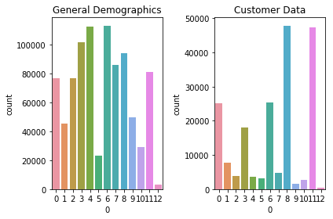

```python
fig, ax = plt.subplots(1, 2)
sb.countplot(data=df_test.transpose(),x=0, ax=ax[0])
sb.countplot(data = df_test2.transpose(), x=0, ax=ax[1])
#sb.countplot(data=pd.DataFrame(kmeans_transform2[8]), x = 'Column_H', ax=ax2)

ax[0].set_title('General Demographics')
ax[1].set_title('Customer Data')
fig.tight_layout()
fig.show()

# every run has different clusters being over represented for 2 clusters, though seems to be the same detection by the detail below
```

### over-represented --- cluster 8, 11

```python
c1 = pd.DataFrame(pca.inverse_transform(kmeans_cluster_labels2[0][8])).mean(axis=0)
g1 = pd.DataFrame(pca.inverse_transform(kmeans_cluster_labels[0][8])).mean(axis=0)

df_diff1 = pd.DataFrame(c1-g1)
df_diff1.index = list(df_clean.columns)
df_diff1.sort_values(by = 0, ascending = False).head(10)
```

|  | 0 |
| --- | --- |
| ANZ_HAUSHALTE_AKTIV | 0.164442 |
| ANZ_PERSONEN | 0.160996 |
| MIN_GEBAEUDEJAHR | 0.080543 |
| KBA05_ANTG2 | 0.078290 |
| ARBEIT | 0.058491 |
| SHOPPER_TYP | 0.055868 |
| INNENSTADT | 0.055613 |
| lifestage_age_na | 0.048976 |
| SEMIO_MAT | 0.047849 |
| BALLRAUM | 0.047705 |

## Suburbians in new home

```python
c2 = pd.DataFrame(pca.inverse_transform(kmeans_cluster_labels2[0][11])).mean(axis=0)
g2 = pd.DataFrame(pca.inverse_transform(kmeans_cluster_labels[0][11])).mean(axis=0)

df_diff2 = pd.DataFrame(c2-g2)
df_diff2.index = list(df_clean.columns)
df_diff2.sort_values(by = 0, ascending = False).head(10)
```

|  | 0 |
| --- | --- |
| KBA05_ANTG4 | 0.290511 |
| WOHNLAGE | 0.262659 |
| CJT_GESAMTTYP | 0.257113 |
| lifestage_older | 0.214749 |
| PLZ8_HHZ | 0.184520 |
| VERS_TYP | 0.155815 |
| SEMIO_REL | 0.153716 |
| SEMIO_PFLICHT | 0.144456 |
| FINANZ_VORSORGER | 0.136612 |
| SEMIO_KULT | 0.130899 |

## Rural living older higher income, resigned people

- KBA05_ANTG4 - Number of 10+ family houses in the microcell -- HIGH SHARE
- CJT_GESAMTTYP - Advertising-Enthusiast with restricted Cross-Channel-Behaviour
- WOHNLAGE Neighborhood quality (or rural flag) -- RURAL NEIGHBOURHOOD/very poor neighbourhood
- LIFESTAGE_OLDER - high-income earners of higher age from multiperson households
- PLZ8_HHZ Number of households within the PLZ8 region -- HIGHER
- VERS_TYP - INSURANCE TYPOLOGY individualistic-accepting risks
- FINANZ_VORSORGER -- BE PREPARED LOWER
- SEMIO_PFLIGHT - DUTIFUL - LOW
- SEMIO_REL -- LOW
- SEMIO_KULT -- CULTURAL MINDED -- LOW

```python
def under_represented(n):

    c = pd.DataFrame(pca.inverse_transform(kmeans_cluster_labels2[0][n])).mean(axis=0)
    g = pd.DataFrame(pca.inverse_transform(kmeans_cluster_labels[0][n])).mean(axis=0)

    diff = pd.DataFrame(c-g)
    diff.index = list(df_clean.columns)
    print(diff.sort_values(by = 0, ascending = True).head(10))
```

### under-represented people

Looks like flipped the other side of the 2 represented groups, neverthless highly calibrated group of people who lives in suburb - Rural area for Over/Under represented

```python
under_represented(0)
```

```
                            0
ANZ_HAUSHALTE_AKTIV -0.246663
ANZ_PERSONEN        -0.241495
MIN_GEBAEUDEJAHR    -0.120814
KBA05_ANTG2         -0.117436
ARBEIT              -0.087737
SHOPPER_TYP         -0.083802
INNENSTADT          -0.083420
lifestage_age_na    -0.073464
SEMIO_MAT           -0.071774
BALLRAUM            -0.071557
```

## under-represented

```python
under_represented(1)
```

```
                         0
KBA05_ANTG4      -0.129116
WOHNLAGE         -0.116737
CJT_GESAMTTYP    -0.114273
lifestage_older  -0.095444
PLZ8_HHZ         -0.082009
VERS_TYP         -0.069251
SEMIO_REL        -0.068318
SEMIO_PFLICHT    -0.064203
FINANZ_VORSORGER -0.060717
SEMIO_KULT       -0.058177
```

## Rural living aspiring younger people

- KBA05_ANTG4 - Number of 10+ family houses in the microcell -- LOW SHARE
- CJT_GESAMTTYP - Advertising- and Consumptionminimalist
- WOHNLAGE Neighborhood quality (or rural flag) -- very good neighborhood
- LIFESTAGE_OLDER single low-income and average earners of younger age
- PLZ8_HHZ Number of households within the PLZ8 region -- LOWER
- VERS_TYP - social-safety driven
- FINANZ_VORSORGER -- BE PREPARED HIGHER
- SEMIO_PFLIGHT - DUTIFUL - HIGH
- SEMIO_REL -- HIGHER
- SEMIO_KULT -- CULTURAL MINDED -- HIGHER

```python
under_represented(2)
```

```
                            0
ANZ_HAUSHALTE_AKTIV -0.082221
ANZ_PERSONEN        -0.080498
MIN_GEBAEUDEJAHR    -0.040271
KBA05_ANTG2         -0.039145
ARBEIT              -0.029246
SHOPPER_TYP         -0.027934
INNENSTADT          -0.027807
lifestage_age_na    -0.024488
SEMIO_MAT           -0.023925
BALLRAUM            -0.023852
```

### Suburbians in older home NEARER TO CITYCENTRE

```python
under_represented(4)
```

```
                            0
ANZ_HAUSHALTE_AKTIV -0.246663
ANZ_PERSONEN        -0.241495
MIN_GEBAEUDEJAHR    -0.120814
KBA05_ANTG2         -0.117436
ARBEIT              -0.087737
SHOPPER_TYP         -0.083802
INNENSTADT          -0.083420
lifestage_age_na    -0.073464
SEMIO_MAT           -0.071774
BALLRAUM            -0.071557
```

```python
under_represented(5)
```

```
                         0
KBA05_ANTG4      -0.129116
WOHNLAGE         -0.116737
CJT_GESAMTTYP    -0.114273
lifestage_older  -0.095444
PLZ8_HHZ         -0.082009
VERS_TYP         -0.069251
SEMIO_REL        -0.068318
SEMIO_PFLICHT    -0.064203
FINANZ_VORSORGER -0.060717
SEMIO_KULT       -0.058177
```

```python
under_represented(10)
```

```
                            0
ANZ_HAUSHALTE_AKTIV -0.082221
ANZ_PERSONEN        -0.080498
MIN_GEBAEUDEJAHR    -0.040271
KBA05_ANTG2         -0.039145
ARBEIT              -0.029246
SHOPPER_TYP         -0.027934
INNENSTADT          -0.027807
lifestage_age_na    -0.024488
SEMIO_MAT           -0.023925
BALLRAUM            -0.023852
```

# Discussion 3.3: Compare Customer Data to Demographics Data

### My Findings:

Suburbian in new homes Rural living older people

seems mail order is targeting suburbian - rural area people

### Under represented groups -- unpopular with mail order company

under-represented are population of the flipped the other side of the above over-represented people

Group of younger, lower-income, better access to city are under-represented and 'dis-liked' by mail order company

Suburbian in older home NEARER TO CITY CENTRE Rural living aspiring younger generations

In both ways, mail order company is focusing on suburbian-rural living group Same area of living but economic/wealth situation is at the opposite direction Seems over-represented people are further from city, little resigned mentally, no interest in cluture etc. Under-represented people are younger and having better access to city, they might just 'go' shopping in person

> Congratulations on making it this far in the project! Before you finish, make sure to check through the entire notebook from top to bottom to make sure that your analysis follows a logical flow and all of your findings are documented in **Discussion** cells. Once you've checked over all of your work, you should export the notebook as an HTML document to submit for evaluation. You can do this from the menu, navigating to **File -> Download as -> HTML (.html)**. You will submit both that document and this notebook for your project submission.